# Calculating Walking and cycling trips impedance function- 1998

# Active-transport walking and cycling behaviour in Canada

## Data and Method

Data on walking and cycling trips to different destinations was derived from Canada’s General Social Survey (GSS) from 1986 to 2015. GSS is a social trends survey in order to monitor changes in the living conditions and well-being of Canadians and to provide information on specific social policy issues. one of the important information of GSS is about Time-use surveys. This survey collects information on all human activities and can therefore inform a broad range of policies. Statistics Canada has been conducting time-use surveys since 1986 at approximately five- to seven- year intervals, most recently in 2015.The GSS on time use employs a retrospective 24-hour time diary to collect information on respondents’ participation in, and time spent on, a wide variety of day-to-day activities. In addition, information is collected on the location where these activities occurred (e.g., at home, at work, etc.).in addition, This dataset contains travel time data of Many of the Census Metropolitan Areas (CMAs) and non-CMA areas all over Canada. CMAs are including St. John’s, Halifax, Saint John, Montreal, Quebec City, Toronto, Ottawa, Hamilton, Winnipeg, Regina, Saskatoon, Calgary, Edmonton, and Vancouver. and the non-CMA areas of each of the ten provinces were also grouped to form ten more strata.

walking and cycling data are categorized based on the three different destinations such as home, school and work, and others’ homes. every episode includes, the start and end time of each event, duration, weight, and concurrent contextual information, such as the location of the activities (e.g., home, work, schools,…).

# Result

First load all of the libraries

Here, we are loading all the primary files of the GSS dataset to create our database for analysis.

### Calculating impedance function for walking in 1998

```r
count <- sum(walking_1998$DURATION > 100)
print (count)
```

```
[1] 12
```

```r
walking_1998 <- walking_1998 %>% filter(DURATION < 100)
summary(walking_1998$DURATION)
```

```
   Min. 1st Qu.  Median    Mean 3rd Qu.    Max.
   1.00    5.00    5.00   10.25   15.00   90.00
```

using a skew vs. kurtois graph to descriptive statistics of data:

```
summary statistics
------
min:  1   max:  90
median:  5
mean:  10.24562
estimated sd:  11.86312
estimated skewness:  2.996226
estimated kurtosis:  15.25708
```

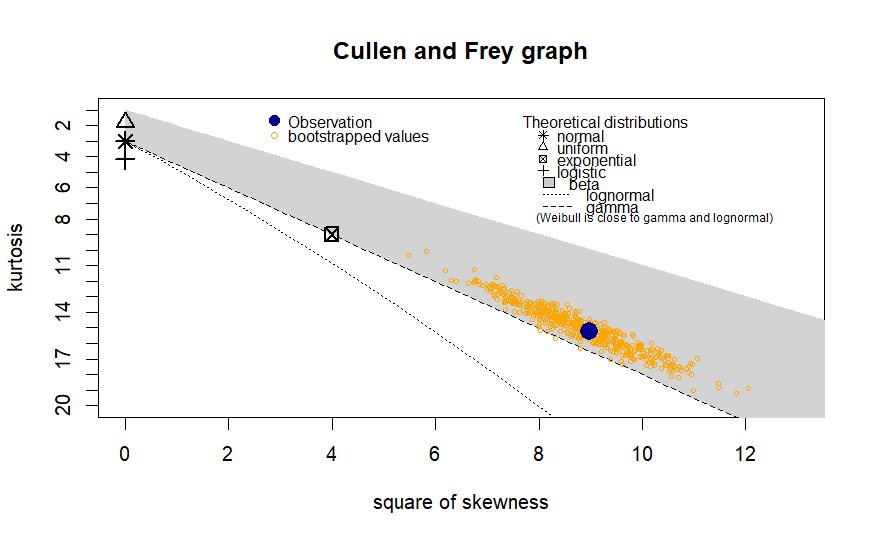

```r
# creating a skew vs. kurtois graph for walking 1998

descdist(walking_1998$DURATION %>% unlist() %>% as.numeric(), discrete=FALSE, boot=500)
```

As shown in the Cullen and Frey graph, we see that gamma and exponential will likely be the best fit according to the graph above. Then we compare these models to find the best model.

```r
# Based on the skew vs. kurtois graph the best distribution

#Calculating gamma distribution

gamma_w_1998_ <- fitdistrplus::fitdist(data=walking_1998$DURATION%>% unlist() %>% as.numeric(), "gamma", method="mle", optim.method="Nelder-Mead", weights = round(walking_1998$WGHT_EPI))
fit_dgamma <- data.frame(f = dgamma(walking_1998$DURATION, shape = gamma_w_1998_$estimate[1], rate = gamma_w_1998_$estimate[2]), x = walking_1998$DURATION, type = "Gamma")

summary(gamma_w_1998_)
```

```
Fitting of the distribution ' gamma ' by maximum likelihood
Parameters :
```

|  | estimate | Std. Error |
| --- | --- | --- |
| shape | 1.2343339 | 8.596015e-04 |
| rate | 0.1163134 | 9.933158e-05 |

```
Loglikelihood:  -11097829   AIC:  22195662   BIC:  22195673
Correlation matrix:
          shape      rate
shape 1.0000000 0.8153677
rate  0.8153677 1.0000000
```

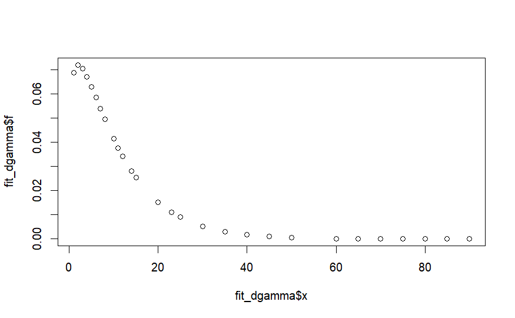

```r
plot(x= fit_dgamma$x, y=fit_dgamma$f)
```

```r
#Calculating weibull distribution

weibull_w_1998_ <- fitdistrplus::fitdist(data=walking_1998$DURATION%>% unlist() %>% as.numeric(), "weibull", method="mle", optim.method="Nelder-Mead", weights = round(walking_1998$WGHT_EPI))
fit_dweibull <- data.frame(f = dweibull(walking_1998$DURATION, shape = weibull_w_1998_$estimate[1], scale = weibull_w_1998_$estimate[2]), x = walking_1998$DURATION, type = "weibull")

summary(weibull_w_1998_)
```

```
Fitting of the distribution ' weibull ' by maximum likelihood
Parameters :
```

|  | estimate | Std. Error |
| --- | --- | --- |
| shape | 1.058536 | 0.0004203369 |
| scale | 10.885848 | 0.0059915174 |

```
Loglikelihood:  -11131112   AIC:  22262228   BIC:  22262239
Correlation matrix:
          shape     scale
shape 1.0000000 0.3338493
scale 0.3338493 1.0000000
```

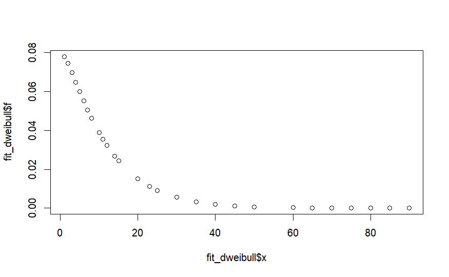

```r
plot(x= fit_dweibull$x, y=fit_dweibull$f)
```

```r
#Calculating exponential distribution
exp_w_1998_ <- fitdistrplus::fitdist(data=walking_1998$DURATION%>% unlist() %>% as.numeric(), "exp", method="mle", optim.method="Nelder-Mead", weights = round(walking_1998$WGHT_EPI))
summary(exp_w_1998_)
```

```
Fitting of the distribution ' exp ' by maximum likelihood
Parameters :
```

|  | estimate | Std. Error |
| --- | --- | --- |
| rate | 0.09420942 | 5.174727e-05 |

```
Loglikelihood:  -11140994   AIC:  22281990   BIC:  22281995
```

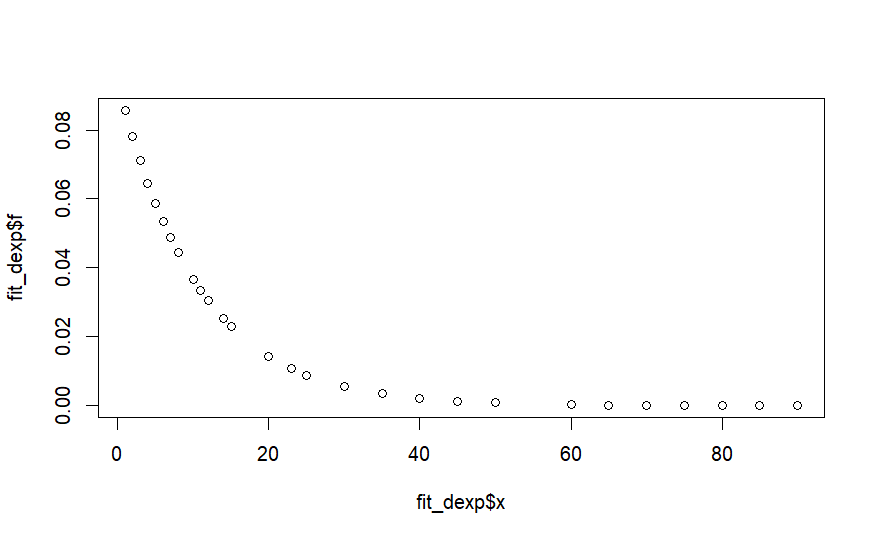

```r
# Get the estimated rate parameter from the fitted distribution
rate_estimate <- exp_w_1998_$estimate[1]

# Create a data frame for the fitted exponential distribution
fit_dexp <- data.frame(f = dexp(walking_1998$DURATION, rate = rate_estimate),
                       x = walking_1998$DURATION, type = "exp")

# Plot the fitted exponential distribution
plot(x = fit_dexp$x, y = fit_dexp$f)
```

Now let’s compare these models based on AIC and BIC to see which fits the walk data best:

```r
#comparing these models AIC and BIC to see which fits the walk data best:
broom::glance(MASS::fitdistr(walking_1998$DURATION%>% unlist() %>% as.numeric(),"gamma"))
```

| logLik | AIC | BIC | nobs |
| --- | --- | --- | --- |
| -5498.721 | 11001.44 | 11012.27 | 1657 |

```r
broom::glance(MASS::fitdistr(walking_1998$DURATION%>% unlist() %>% as.numeric(),"weibull"))
```

| logLik | AIC | BIC | nobs |
| --- | --- | --- | --- |
| -5511.106 | 11026.21 | 11037.04 | 1657 |

```r
broom::glance(MASS::fitdistr(walking_1998$DURATION%>% unlist() %>% as.numeric(),"exponential"))
```

| logLik | AIC | BIC | nobs |
| --- | --- | --- | --- |
| -5512.592 | 11027.18 | 11032.6 | 1657 |

```r
walking_1998_weibull <- weibull_w_1998_
walking_1998 <- walking_1998 %>%
 mutate(f = dweibull(DURATION, walking_1998_weibull$estimate["shape"], walking_1998_weibull$estimate["scale"]))
summary(walking_1998$f)
```

```
     Min.   1st Qu.    Median      Mean   3rd Qu.      Max.
9.510e-06 2.433e-02 5.991e-02 4.857e-02 5.991e-02 7.807e-02
```

### Destination : Home (1)- 1998

using a skew vs. kurtois graph to descriptive statistics of data

```
summary statistics
------
min:  1   max:  90
median:  5
mean:  10.30035
estimated sd:  12.33592
estimated skewness:  3.112208
estimated kurtosis:  15.72597
```

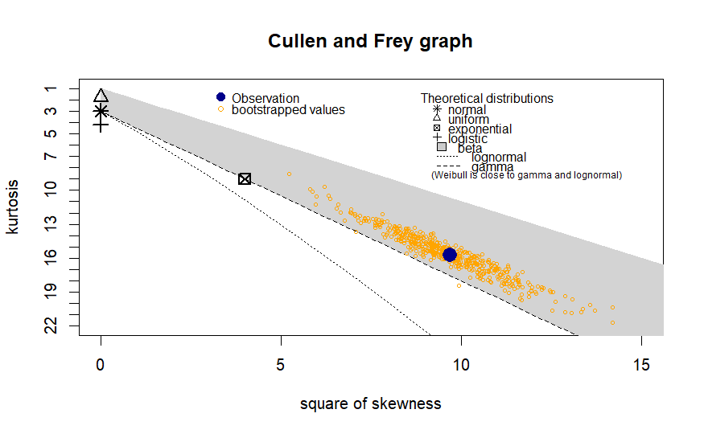

```r
# creating a skew vs. kurtois graph for walking 1998

# Filter the data based on the "destination" column
 w_1_1998 <- walking_1998 %>%
  filter(destination == "1")
descdist(w_1_1998$DURATION %>% unlist() %>% as.numeric(), discrete=FALSE, boot=500)
```

As shown in the Cullen and Frey graph, we see that gamma and exponential will likely be the best fit according to the graph above. Then we compare these models to find the best model.

```r
# Based on the skew vs. kurtois graph the best distribution

#Calculating gamma distribution
gamma_w1_1998_ <- fitdistrplus::fitdist(data=w_1_1998$DURATION%>% unlist() %>% as.numeric(), "gamma", method="mle", optim.method="Nelder-Mead", weights = round(w_1_1998$WGHT_EPI))
fit_dgamma_w198 <- data.frame(f = dgamma(w_1_1998$DURATION, shape = gamma_w1_1998_$estimate[1], rate = gamma_w1_1998_$estimate[2]), x = w_1_1998$DURATION, type = "Gamma")

summary(gamma_w1_1998_)
```

```
Fitting of the distribution ' gamma ' by maximum likelihood
Parameters :
```

|  | estimate | Std. Error |
| --- | --- | --- |
| shape | 1.2389998 | 0.0012006086 |
| rate | 0.1176975 | 0.0001397565 |

```
Loglikelihood:  -5721318   AIC:  11442639   BIC:  11442649
Correlation matrix:
          shape      rate
shape 1.0000000 0.8159682
rate  0.8159682 1.0000000
```

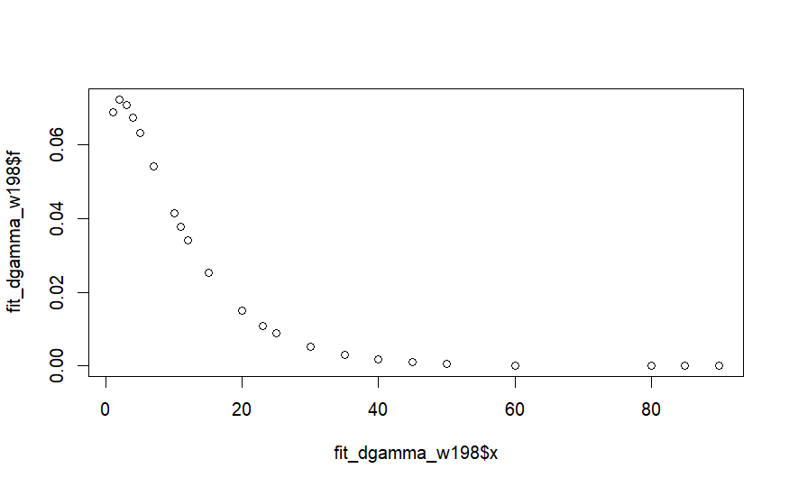

```r
plot(x= fit_dgamma_w198$x, y=fit_dgamma_w198$f)
```

```r
#Calculating exponential distribution
exp_w1_1998_ <- fitdistrplus::fitdist(data=w_1_1998$DURATION%>% unlist() %>% as.numeric(), "exp", method="mle", optim.method="Nelder-Mead", weights = round(w_1_1998$WGHT_EPI))
summary(exp_w1_1998_)
```

```
Fitting of the distribution ' exp ' by maximum likelihood
Parameters :
```

|  | estimate | Std. Error |
| --- | --- | --- |
| rate | 0.09496033 | 7.255483e-05 |

```
Loglikelihood:  -5744394   AIC:  11488790   BIC:  11488795
```

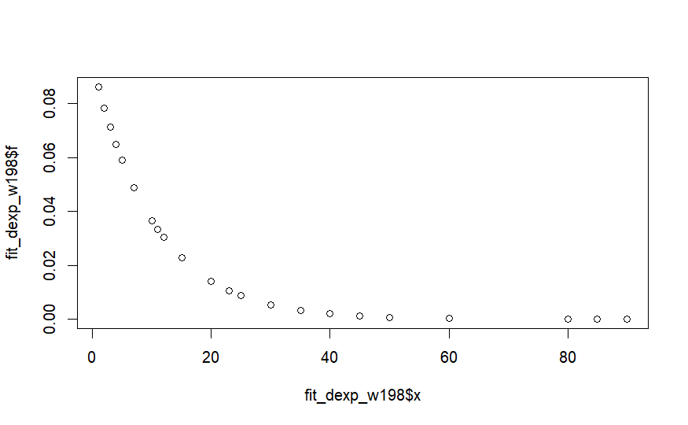

```r
fit_dexp_w198 <- data.frame(f = dexp(w_1_1998$DURATION, rate = exp_w1_1998_$estimate[1]),
                       x = w_1_1998$DURATION, type = "exp")

plot(x = fit_dexp_w198$x, y = fit_dexp_w198$f)
```

Now let’s compare these models AIC and BIC to see which fits the walk data best:

```r
#comparing these models AIC and BIC to see which fits the walk data best:
broom::glance(MASS::fitdistr(w_1_1998$DURATION%>% unlist() %>% as.numeric(),"gamma"))
```

| logLik | AIC | BIC | nobs |
| --- | --- | --- | --- |
| -2822.99 | 5649.981 | 5659.469 | 849 |

```r
broom::glance(MASS::fitdistr(w_1_1998$DURATION%>% unlist() %>% as.numeric(),"exponential"))
```

| logLik | AIC | BIC | nobs |
| --- | --- | --- | --- |
| -2829.019 | 5660.039 | 5664.783 | 849 |

So, gamma has largest logLik and the smallest AIC and BIC. we will pick gamma function for walking trips in 1998!

```r
walking_198_gamma <- gamma_w1_1998_
w_1_1998 <- w_1_1998 %>%
 mutate(f_1 = dgamma(DURATION, walking_198_gamma$estimate["shape"], walking_198_gamma$estimate["rate"]))
summary(w_1_1998$f_1)
```

```
     Min.   1st Qu.    Median      Mean   3rd Qu.      Max.
5.710e-06 2.539e-02 6.335e-02 4.965e-02 6.335e-02 7.244e-02
```

### Destination : Work place (2)- 1998

using a skew vs. kurtois graph to descriptive statistics of data

```
summary statistics
------
min:  1   max:  75
median:  6.5
mean:  11.74118
estimated sd:  11.82533
estimated skewness:  2.089206
estimated kurtosis:  8.655191
```

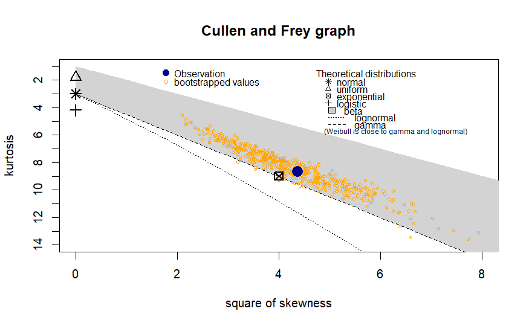

```r
# creating a skew vs. kurtois graph for walking 1998

# Filter the data based on the "destination" column
 w_2_1998 <- walking_1998 %>%
  filter(destination == "2")
descdist(w_2_1998$DURATION %>% unlist() %>% as.numeric(), discrete=FALSE, boot=500)
```

As shown in the Cullen and Frey graph, we see that gamma and exponential will likely be the best fit according to the graph above. Then we compare these models to find the best model.

```r
# Based on the skew vs. kurtois graph the best distribution

#Calculating gamma distribution
gamma_w2_1998_ <- fitdistrplus::fitdist(data=w_2_1998$DURATION%>% unlist() %>% as.numeric(), "gamma", method="mle", optim.method="Nelder-Mead", weights = round(w_2_1998$WGHT_EPI))
fit_dgamma_w298 <- data.frame(f = dgamma(w_2_1998$DURATION, shape = gamma_w2_1998_$estimate[1], rate = gamma_w2_1998_$estimate[2]), x = w_2_1998$DURATION, type = "Gamma")

summary(gamma_w2_1998_)
```

```
Fitting of the distribution ' gamma ' by maximum likelihood
Parameters :
```

|  | estimate | Std. Error |
| --- | --- | --- |
| shape | 1.24761521 | 0.0019225628 |
| rate | 0.09912684 | 0.0001869258 |

```
Loglikelihood:  -2385037   AIC:  4770077   BIC:  4770085
Correlation matrix:
          shape      rate
shape 1.0000000 0.8170494
rate  0.8170494 1.0000000
```

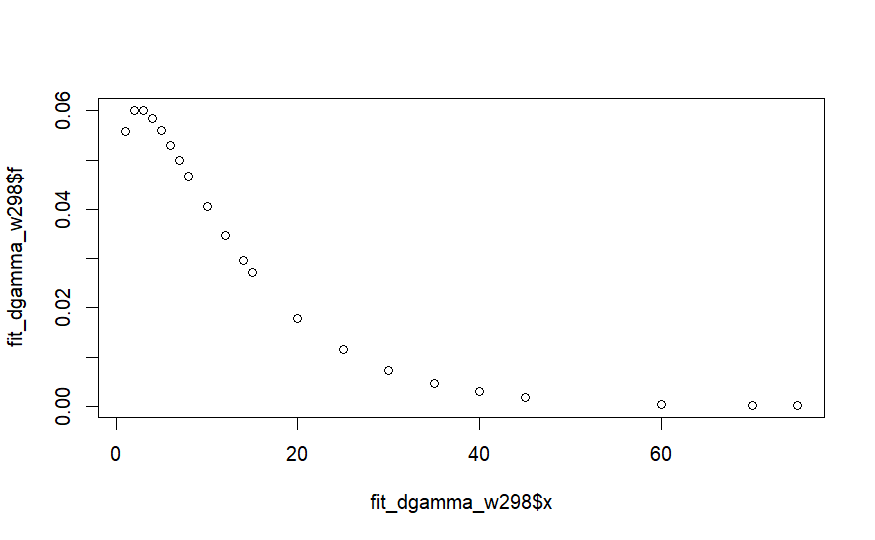

```r
plot(x= fit_dgamma_w298$x, y=fit_dgamma_w298$f)
```

```r
#Calculating exponential distribution
exp_w2_1998_ <- fitdistrplus::fitdist(data=w_2_1998$DURATION%>% unlist() %>% as.numeric(), "exp", method="mle", optim.method="Nelder-Mead", weights = round(w_2_1998$WGHT_EPI))
summary(exp_w2_1998_)
```

```
Fitting of the distribution ' exp ' by maximum likelihood
Parameters :
```

|  | estimate | Std. Error |
| --- | --- | --- |
| rate | 0.07944796 | 9.647763e-05 |

```
Loglikelihood:  -2394759   AIC:  4789520   BIC:  4789524
```

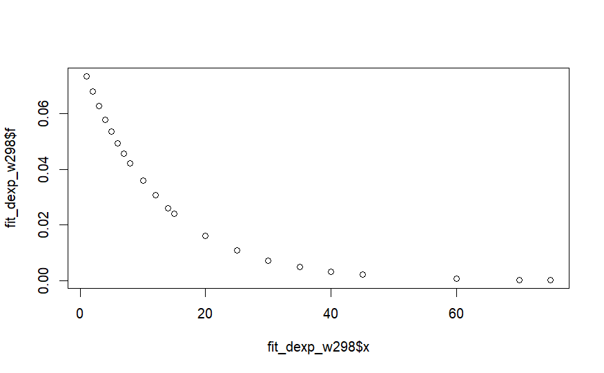

```r
fit_dexp_w298 <- data.frame(f = dexp(w_2_1998$DURATION, rate = exp_w2_1998_$estimate[1]),
                       x = w_2_1998$DURATION, type = "exp")

plot(x = fit_dexp_w298$x, y = fit_dexp_w298$f)
```

Now let’s compare these models AIC and BIC to see which fits the walk data best:

```r
#comparing these models AIC and BIC to see which fits the walk data best:
broom::glance(MASS::fitdistr(w_2_1998$DURATION%>% unlist() %>% as.numeric(),"gamma"))
```

| logLik | AIC | BIC | nobs |
| --- | --- | --- | --- |
| -1173.767 | 2351.535 | 2359.192 | 340 |

```r
broom::glance(MASS::fitdistr(w_2_1998$DURATION%>% unlist() %>% as.numeric(),"exponential"))
```

| logLik | AIC | BIC | nobs |
| --- | --- | --- | --- |
| -1177.455 | 2356.909 | 2360.738 | 340 |

So, gamma has largest logLik and the smallest AIC and BIC. we will pick gamma function for walking trips in 1998!

```r
walking_298_gamma <- gamma_w2_1998_
w_2_1998 <- w_2_1998 %>%
 mutate(f_2 = dgamma(DURATION, walking_298_gamma$estimate["shape"], walking_298_gamma$estimate["rate"]))
summary(w_2_1998$f_2)
```

```
     Min.   1st Qu.    Median      Mean   3rd Qu.      Max.
0.0001061 0.0272608 0.0514542 0.0406934 0.0559628 0.0601266
```

### Destination : Other’s Home (3)- 1998

using a skew vs. kurtois graph to descriptive statistics of data

```
summary statistics
------
min:  1   max:  90
median:  5
mean:  9.059829
estimated sd:  10.8705
estimated skewness:  3.564344
estimated kurtosis:  21.15811
```

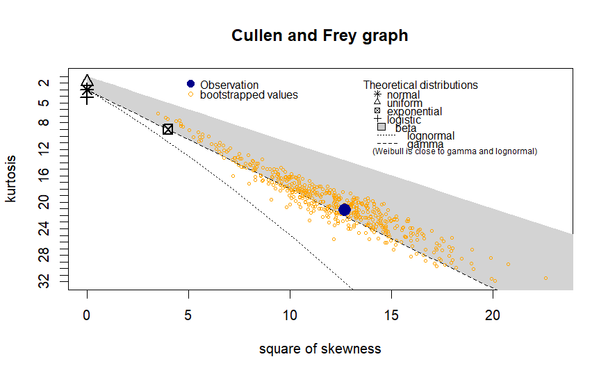

```r
# creating a skew vs. kurtois graph for walking 1998

# Filter the data based on the "destination" column
 w_3_1998 <- walking_1998 %>%
  filter(destination == "3")
descdist(w_3_1998$DURATION %>% unlist() %>% as.numeric(), discrete=FALSE, boot=500)
```

As shown in the Cullen and Frey graph, we see that gamma, weibull and exponential will likely be the best fit according to the graph above. Then we compare these models to find the best model.

```r
# Based on the skew vs. kurtois graph the best distribution

#Calculating gamma distribution
gamma_w3_1998_ <- fitdistrplus::fitdist(data=w_3_1998$DURATION%>% unlist() %>% as.numeric(), "gamma", method="mle", optim.method="Nelder-Mead", weights = round(w_3_1998$WGHT_EPI))
fit_dgamma_w398 <- data.frame(f = dgamma(w_3_1998$DURATION, shape = gamma_w3_1998_$estimate[1], rate = gamma_w3_1998_$estimate[2]), x = w_3_1998$DURATION, type = "Gamma")

summary(gamma_w3_1998_)
```

```
Fitting of the distribution ' gamma ' by maximum likelihood
Parameters :
```

|  | estimate | Std. Error |
| --- | --- | --- |
| shape | 1.2639312 | 0.0016708926 |
| rate | 0.1356837 | 0.0002189606 |

```
Loglikelihood:  -2969109   AIC:  5938221   BIC:  5938230
Correlation matrix:
          shape      rate
shape 1.0000000 0.8191197
rate  0.8191197 1.0000000
```

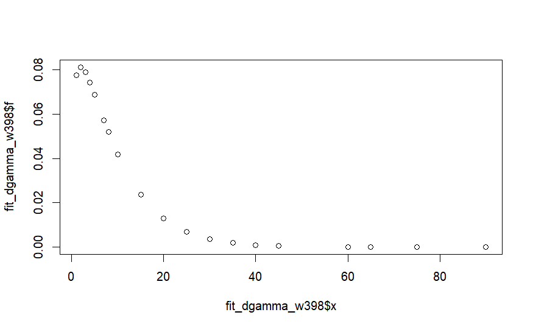

```r
plot(x= fit_dgamma_w398$x, y=fit_dgamma_w398$f)
```

```r
#Calculating weibull distribution
weibull_w3_1998_ <- fitdistrplus::fitdist(data=w_3_1998$DURATION%>% unlist() %>% as.numeric(), "weibull", method="mle", optim.method="Nelder-Mead", weights = round(w_3_1998$WGHT_EPI))
fit_dweibull_w398 <- data.frame(f = dweibull(w_3_1998$DURATION, shape = weibull_w3_1998_$estimate[1], scale = weibull_w3_1998_$estimate[2]), x = w_3_1998$DURATION, type = "weibull")

summary(weibull_w3_1998_)
```

```
Fitting of the distribution ' weibull ' by maximum likelihood
Parameters :
```

|  | estimate | Std. Error |
| --- | --- | --- |
| shape | 1.053648 | 0.0007740209 |
| scale | 9.549719 | 0.0100146987 |

```
Loglikelihood:  -2981420   AIC:  5962844   BIC:  5962853
Correlation matrix:
          shape     scale
shape 1.0000000 0.3358142
scale 0.3358142 1.0000000
```

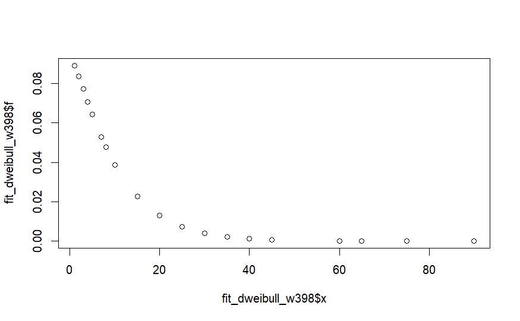

```r
plot(x= fit_dweibull_w398$x, y=fit_dweibull_w398$f)
```

```r
#Calculating exponential distribution
exp_w3_1998_ <- fitdistrplus::fitdist(data=w_3_1998$DURATION%>% unlist() %>% as.numeric(), "exp", method="mle", optim.method="Nelder-Mead", weights = round(w_3_1998$WGHT_EPI))
summary(exp_w3_1998_)
```

```
Fitting of the distribution ' exp ' by maximum likelihood
Parameters :
```

|  | estimate | Std. Error |
| --- | --- | --- |
| rate | 0.1073161 | 0.0001116805 |

```
Loglikelihood:  -2983880   AIC:  5967763   BIC:  5967767
```

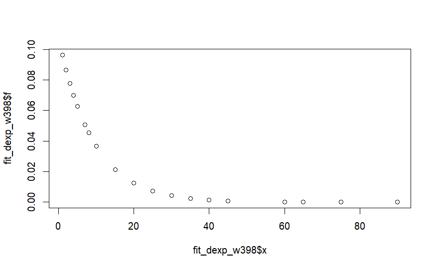

```r
fit_dexp_w398 <- data.frame(f = dexp(w_3_1998$DURATION, rate = exp_w3_1998_$estimate[1]),
                       x = w_3_1998$DURATION, type = "exp")

plot(x = fit_dexp_w398$x, y = fit_dexp_w398$f)
```

Now let’s compare these models AIC and BIC to see which fits the walk data best:

```r
#comparing these models AIC and BIC to see which fits the walk data best:
broom::glance(MASS::fitdistr(w_3_1998$DURATION%>% unlist() %>% as.numeric(),"gamma"))
```

| logLik | AIC | BIC | nobs |
| --- | --- | --- | --- |
| -1493.732 | 2991.465 | 2999.762 | 468 |

```r
broom::glance(MASS::fitdistr(w_3_1998$DURATION%>% unlist() %>% as.numeric(),"weibull"))
```

| logLik | AIC | BIC | nobs |
| --- | --- | --- | --- |
| -1498.737 | 3001.474 | 3009.771 | 468 |

```r
broom::glance(MASS::fitdistr(w_3_1998$DURATION%>% unlist() %>% as.numeric(),"exponential"))
```

| logLik | AIC | BIC | nobs |
| --- | --- | --- | --- |
| -1499.402 | 3000.804 | 3004.952 | 468 |

So, gamma has largest logLik and the smallest AIC and BIC. we will pick gamma function for walking trips in 1998!

```r
walking_398_gamma <- gamma_w3_1998_
w_3_1998 <- w_3_1998 %>%
 mutate(f_3 = dgamma(DURATION, walking_398_gamma$estimate["shape"], walking_398_gamma$estimate["rate"]))
summary(w_3_1998$f_3)
```

```
     Min.   1st Qu.    Median      Mean   3rd Qu.      Max.
1.450e-06 4.190e-02 6.877e-02 5.621e-02 6.877e-02 8.113e-02
```

### Calculating impedance function for cycling in 1998

```r
count <- sum(cycling_1998$DURATION > 100)
print (count)
```

```
[1] 0
```

```r
cycling_1998 <- cycling_1998 %>% filter(DURATION < 100)
summary(cycling_1998$DURATION)
```

```
   Min. 1st Qu.  Median    Mean 3rd Qu.    Max.
   2.00   10.00   15.00   20.61   30.00   90.00
```

using a skew vs. kurtois graph to descriptive statistics of data:

```
summary statistics
------
min:  2   max:  90
median:  15
mean:  20.60504
estimated sd:  18.34242
estimated skewness:  1.878686
estimated kurtosis:  6.664037
```

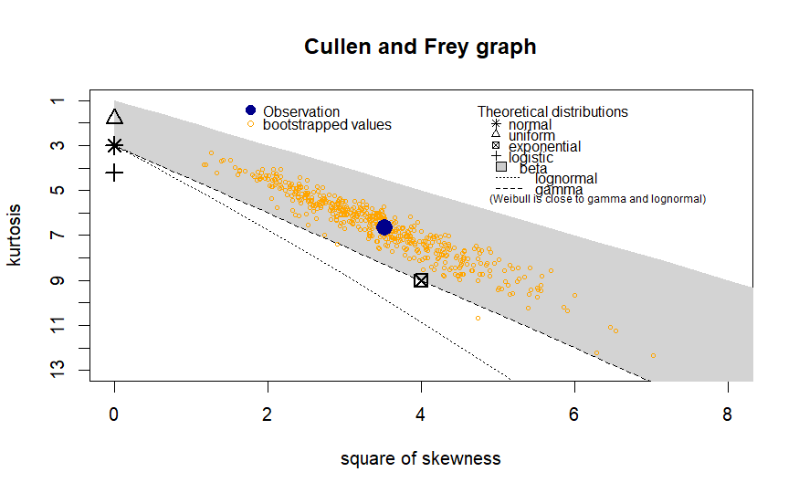

```r
# creating a skew vs. kurtois graph for cycling 1998

descdist(cycling_1998$DURATION %>% unlist() %>% as.numeric(), discrete=FALSE, boot=500)
```

As shown in the Cullen and Frey graph, we see that gamma and exponential will likely be the best fit according to the graph above. Then we compare these models to find the best model.

```r
summary(cycling_1998$DURATION)
```

```
   Min. 1st Qu.  Median    Mean 3rd Qu.    Max.
   2.00   10.00   15.00   20.61   30.00   90.00
```

```r
# Based on the skew vs. kurtois graph the best distribution

#Calculating gamma distribution

gamma_c_1998_ <- fitdistrplus::fitdist(data=cycling_1998$DURATION%>% unlist() %>% as.numeric(), "gamma", method="mle", optim.method="Nelder-Mead", weights = round(cycling_1998$WGHT_EPI))
fit_dgamma <- data.frame(f = dgamma(cycling_1998$DURATION, shape = gamma_c_1998_$estimate[1], rate = gamma_c_1998_$estimate[2]), x = cycling_1998$DURATION, type = "gamma")

summary(gamma_c_1998_)
```

```
Fitting of the distribution ' gamma ' by maximum likelihood
Parameters :
```

|  | estimate | Std. Error |
| --- | --- | --- |
| shape | 1.70058219 | 0.0043047954 |
| rate | 0.07007897 | 0.0002059478 |

```
Loglikelihood:  -1083608   AIC:  2167220   BIC:  2167225
Correlation matrix:
          shape      rate
shape 1.0000000 0.8610692
rate  0.8610692 1.0000000
```

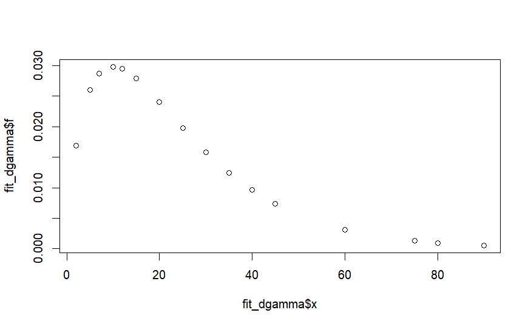

```r
plot(x= fit_dgamma$x, y=fit_dgamma$f)
```

```r
#Calculating exponential distribution
exp_c_1998_ <- fitdistrplus::fitdist(data=cycling_1998$DURATION%>% unlist() %>% as.numeric(), "exp", method="mle", optim.method="Nelder-Mead", weights = round(cycling_1998$WGHT_EPI))
summary(exp_c_1998_)
```

```
Fitting of the distribution ' exp ' by maximum likelihood
Parameters :
```

|  | estimate | Std. Error |
| --- | --- | --- |
| rate | 0.04121412 | 8.02837e-05 |

```
Loglikelihood:  -1102690   AIC:  2205383   BIC:  2205386
```

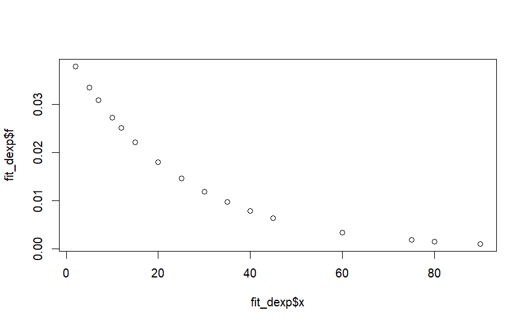

```r
fit_dexp <- data.frame(f = dexp(cycling_1998$DURATION, rate = exp_c_1998_$estimate[1]), x = cycling_1998$DURATION, type = "exp")

plot(x= fit_dexp$x, y=fit_dexp$f)
```

Now let’s compare these models based on AIC and BIC to see which fits the walk data best:

```r
#comparing these models AIC and BIC to see which fits the walk data best:
broom::glance(MASS::fitdistr(cycling_1998$DURATION%>% unlist() %>% as.numeric(),"gamma"))
```

| logLik | AIC | BIC | nobs |
| --- | --- | --- | --- |
| -471.6509 | 947.3018 | 952.86 | 119 |

```r
broom::glance(MASS::fitdistr(cycling_1998$DURATION%>% unlist() %>% as.numeric(),"exponential"))
```

| logLik | AIC | BIC | nobs |
| --- | --- | --- | --- |
| -479.0388 | 960.0775 | 962.8566 | 119 |

So, gamma has largest logLik and the smallest AIC and BIC. we will pick gamma function for cycling trips in 1998!

```r
cycling_1998_gamma <- gamma_c_1998_
cycling_1998 <- cycling_1998 %>%
 mutate(f = dgamma(DURATION, cycling_1998_gamma$estimate["shape"] , cycling_1998_gamma$estimate["rate"]))
summary(cycling_1998$f)
```

```
     Min.   1st Qu.    Median      Mean   3rd Qu.      Max.
0.0005109 0.0158555 0.0260552 0.0222433 0.0279131 0.0298274
```

### Destination : Cycling - Home (1), 1998

using a skew vs. kurtois graph to descriptive statistics of data

```
summary statistics
------
min:  2   max:  90
median:  15
mean:  20.52381
estimated sd:  19.37895
estimated skewness:  1.98297
estimated kurtosis:  7.154267
```

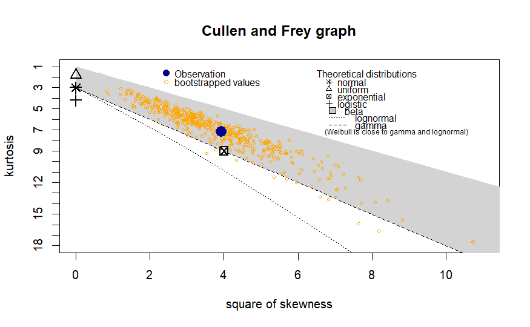

```r
# creating a skew vs. kurtois graph for cycling 1998

# Filter the data based on the "destination" column
 c_1_1998 <- cycling_1998 %>%
  filter(destination == "1")
descdist(c_1_1998$DURATION %>% unlist() %>% as.numeric(), discrete=FALSE, boot=500)
```

As shown in the Cullen and Frey graph, we see that gamma and exponential will likely be the best fit according to the graph above. Then we compare these models to find the best model.

```r
# Based on the skew vs. kurtois graph the best distribution

#Calculating gamma distribution
gamma_c1_1998_ <- fitdistrplus::fitdist(data=c_1_1998$DURATION%>% unlist() %>% as.numeric(), "gamma", method="mle", optim.method="Nelder-Mead", weights = round(c_1_1998$WGHT_EPI))
fit_dgamma_c198 <- data.frame(f = dgamma(c_1_1998$DURATION, shape = gamma_c1_1998_$estimate[1], rate = gamma_c1_1998_$estimate[2]), x = c_1_1998$DURATION, type = "Gamma")

summary(gamma_c1_1998_)
```

```
Fitting of the distribution ' gamma ' by maximum likelihood
Parameters :
```

|  | estimate | Std. Error |
| --- | --- | --- |
| shape | 1.50785076 | 0.0052690791 |
| rate | 0.06391914 | 0.0002642004 |

```
Loglikelihood:  -558555.8   AIC:  1117116   BIC:  1117120
Correlation matrix:
          shape      rate
shape 1.0000000 0.8450776
rate  0.8450776 1.0000000
```

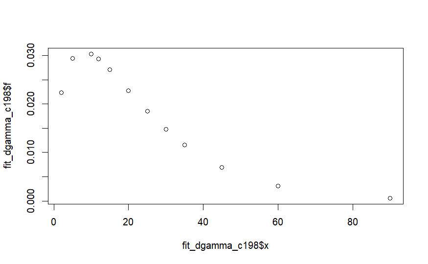

```r
plot(x= fit_dgamma_c198$x, y=fit_dgamma_c198$f)
```

```r
#Calculating exponential distribution
exp_c1_1998_ <- fitdistrplus::fitdist(data=c_1_1998$DURATION%>% unlist() %>% as.numeric(), "exp", method="mle", optim.method="Nelder-Mead", weights = round(c_1_1998$WGHT_EPI))
summary(exp_c1_1998_)
```

```
Fitting of the distribution ' exp ' by maximum likelihood
Parameters :
```

|  | estimate | Std. Error |
| --- | --- | --- |
| rate | 0.04240502 | 0.0001150345 |

```
Loglikelihood:  -564743.5   AIC:  1129489   BIC:  1129491
```

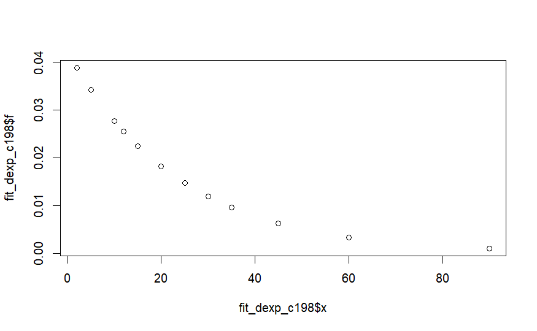

```r
fit_dexp_c198 <- data.frame(f = dexp(c_1_1998$DURATION, rate = exp_c1_1998_$estimate[1]),
                       x = c_1_1998$DURATION, type = "exp")

plot(x = fit_dexp_c198$x, y = fit_dexp_c198$f)
```

Now let’s compare these models AIC and BIC to see which fits the walk data best:

```r
#comparing these models AIC and BIC to see which fits the walk data best:
broom::glance(MASS::fitdistr(c_1_1998$DURATION%>% unlist() %>% as.numeric(),"gamma"))
```

| logLik | AIC | BIC | nobs |
| --- | --- | --- | --- |
| -250.5472 | 505.0944 | 509.3807 | 63 |

```r
broom::glance(MASS::fitdistr(c_1_1998$DURATION%>% unlist() %>% as.numeric(),"exponential"))
```

| logLik | AIC | BIC | nobs |
| --- | --- | --- | --- |
| -253.3599 | 508.7198 | 510.8629 | 63 |

So, gamma has largest logLik and the smallest AIC and BIC. we will pick gamma function for cycling trips in 1998!

```r
cycling_198_gamma <- gamma_c1_1998_
c_1_1998 <- c_1_1998 %>%
 mutate(f_1 = dgamma(DURATION, cycling_198_gamma$estimate["shape"], cycling_198_gamma$estimate["rate"]))
summary(c_1_1998$f_1)
```

```
     Min.   1st Qu.    Median      Mean   3rd Qu.      Max.
0.0005565 0.0147487 0.0270564 0.0226520 0.0293469 0.0303139
```

### Destination :cycling- Work place (2), 1998

using a skew vs. kurtois graph to descriptive statistics of data

```
summary statistics
------
min:  5   max:  75
median:  20
mean:  23.62857
estimated sd:  17.19967
estimated skewness:  1.308248
estimated kurtosis:  4.448523
```

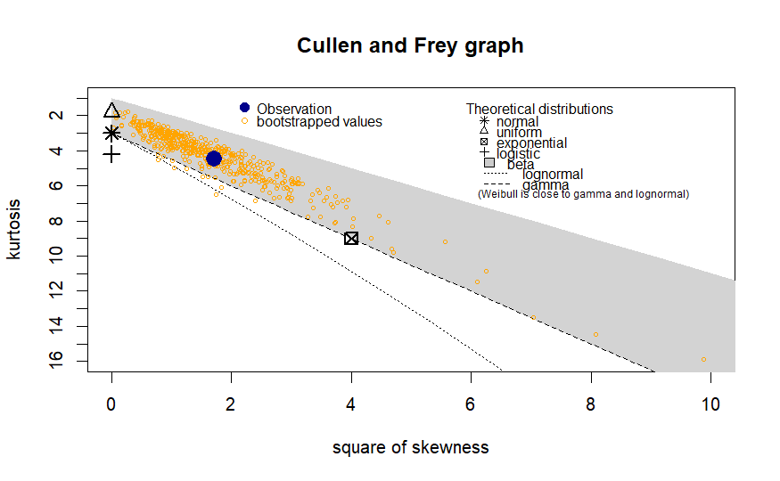

```r
# creating a skew vs. kurtois graph for cycling 1998

# Filter the data based on the "destination" column
 c_2_1998 <- cycling_1998 %>%
  filter(destination == "2")
descdist(c_2_1998$DURATION %>% unlist() %>% as.numeric(), discrete=FALSE, boot=500)
```

As shown in the Cullen and Frey graph, we see that gamma ,weibull, normal and exponential will likely be the best fit according to the graph above. Then we compare these models to find the best model.

```r
# Based on the skew vs. kurtois graph the best distribution

#Calculating gamma distribution
gamma_c2_1998_ <- fitdistrplus::fitdist(data=c_2_1998$DURATION%>% unlist() %>% as.numeric(), "gamma", method="mle", optim.method="Nelder-Mead", weights = round(c_2_1998$WGHT_EPI))
fit_dgamma_c298 <- data.frame(f = dgamma(c_2_1998$DURATION, shape = gamma_c2_1998_$estimate[1], rate = gamma_c2_1998_$estimate[2]), x = c_2_1998$DURATION, type = "Gamma")

summary(gamma_c2_1998_)
```

```
Fitting of the distribution ' gamma ' by maximum likelihood
Parameters :
```

|  | estimate | Std. Error |
| --- | --- | --- |
| shape | 2.64624329 | 0.0120239986 |
| rate | 0.08913712 | 0.0004458585 |

```
Loglikelihood:  -360792.7   AIC:  721589.5   BIC:  721592.6
Correlation matrix:
          shape      rate
shape 1.0000000 0.9082168
rate  0.9082168 1.0000000
```

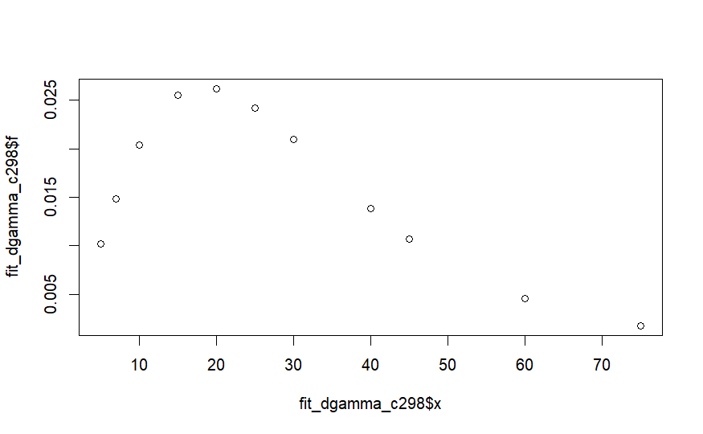

```r
plot(x= fit_dgamma_c298$x, y=fit_dgamma_c298$f)
```

```r
#Calculating weibull distribution
weibull_c2_1998_ <- fitdistrplus::fitdist(data=c_2_1998$DURATION%>% unlist() %>% as.numeric(), "weibull", method="mle", optim.method="Nelder-Mead", weights = round(c_2_1998$WGHT_EPI))
fit_dweibull_c298 <- data.frame(f = dweibull(c_2_1998$DURATION, shape = weibull_c2_1998_$estimate[1], scale = weibull_c2_1998_$estimate[2]), x = c_2_1998$DURATION, type = "weibull")

summary(weibull_c2_1998_)
```

```
Fitting of the distribution ' weibull ' by maximum likelihood
Parameters :
```

|  | estimate | Std. Error |
| --- | --- | --- |
| shape | 1.751484 | 0.004637391 |
| scale | 33.460436 | 0.068737809 |

```
Loglikelihood:  -361315.2   AIC:  722634.3   BIC:  722637.4
Correlation matrix:
          shape     scale
shape 1.0000000 0.3228156
scale 0.3228156 1.0000000
```

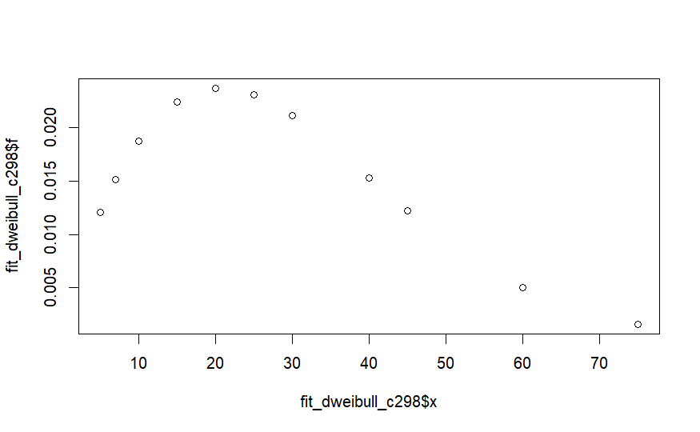

```r
plot(x= fit_dweibull_c298$x, y=fit_dweibull_c298$f)
```

```r
#Calculating normal distribution
norm_c2_1998_ <- fitdistrplus::fitdist(data=c_2_1998$DURATION%>% unlist() %>% as.numeric(), "norm", method="mle", optim.method="Nelder-Mead", weights = round(c_2_1998$WGHT_EPI))
fit_dnorm_c298 <- data.frame(f = dnorm(c_2_1998$DURATION, mean = norm_c2_1998_$estimate[1], sd = norm_c2_1998_$estimate[2]), x = c_2_1998$DURATION, type = "norm")

summary(norm_c2_1998_)
```

```
Fitting of the distribution ' norm ' by maximum likelihood
Parameters :
```

|  | estimate | Std. Error |
| --- | --- | --- |
| mean | 29.69096 | 0.06072497 |
| sd | 17.83051 | 0.04293473 |

```
Loglikelihood:  -370725.9   AIC:  741455.8   BIC:  741458.9
Correlation matrix:
             mean           sd
mean 1.0000000000 0.0004889884
sd   0.0004889884 1.0000000000
```

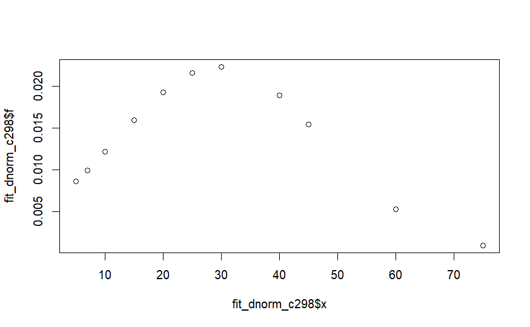

```r
plot(x= fit_dnorm_c298$x, y=fit_dnorm_c298$f)
```

```r
#Calculating exponential distribution
exp_c2_1998_ <- fitdistrplus::fitdist(data=c_2_1998$DURATION%>% unlist() %>% as.numeric(), "exp", method="mle", optim.method="Nelder-Mead", weights = round(c_2_1998$WGHT_EPI))
summary(exp_c2_1998_)
```

```
Fitting of the distribution ' exp ' by maximum likelihood
Parameters :
```

|  | estimate | Std. Error |
| --- | --- | --- |
| rate | 0.033692 | 0.0001146429 |

```
Loglikelihood:  -378547.4   AIC:  757096.8   BIC:  757098.3
```

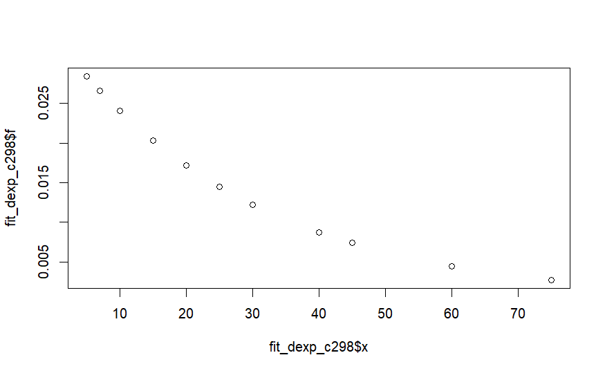

```r
fit_dexp_c298 <- data.frame(f = dexp(c_2_1998$DURATION, rate = exp_c2_1998_$estimate[1]),
                       x = c_2_1998$DURATION, type = "exp")

plot(x = fit_dexp_c298$x, y = fit_dexp_c298$f)
```

Now let’s compare these models AIC and BIC to see which fits the walk data best:

```r
#comparing these models AIC and BIC to see which fits the walk data best:
broom::glance(MASS::fitdistr(c_2_1998$DURATION%>% unlist() %>% as.numeric(),"gamma"))
```

| logLik | AIC | BIC | nobs |
| --- | --- | --- | --- |
| -140.9976 | 285.9953 | 289.106 | 35 |

```r
broom::glance(MASS::fitdistr(c_2_1998$DURATION%>% unlist() %>% as.numeric(),"normal"))
```

| logLik | AIC | BIC | nobs |
| --- | --- | --- | --- |
| -148.7267 | 301.4534 | 304.5641 | 35 |

```r
broom::glance(MASS::fitdistr(c_2_1998$DURATION%>% unlist() %>% as.numeric(),"weibull"))
```

| logLik | AIC | BIC | nobs |
| --- | --- | --- | --- |
| -141.7113 | 287.4225 | 290.5332 | 35 |

```r
broom::glance(MASS::fitdistr(c_2_1998$DURATION%>% unlist() %>% as.numeric(),"exponential"))
```

| logLik | AIC | BIC | nobs |
| --- | --- | --- | --- |
| -145.686 | 293.372 | 294.9273 | 35 |

So, gamma has largest logLik and the smallest AIC and BIC. we will pick gamma function for cycling trips in 1998!

```r
cycling_298_gamma <- gamma_c2_1998_
c_2_1998 <- c_2_1998 %>%
 mutate(f_2 = dgamma(DURATION, cycling_298_gamma$estimate["shape"], cycling_298_gamma$estimate["rate"]))
summary(c_2_1998$f_2)
```

```
    Min.  1st Qu.   Median     Mean  3rd Qu.     Max.
0.001716 0.012267 0.020962 0.018730 0.025500 0.026221
```

### Destination : Cycling - Other’s Home (3), 1998

using a skew vs. kurtois graph to descriptive statistics of data

```
summary statistics
------
min:  2   max:  80
median:  10
mean:  15.80952
estimated sd:  16.66619
estimated skewness:  3.116387
estimated kurtosis:  14.52863
```

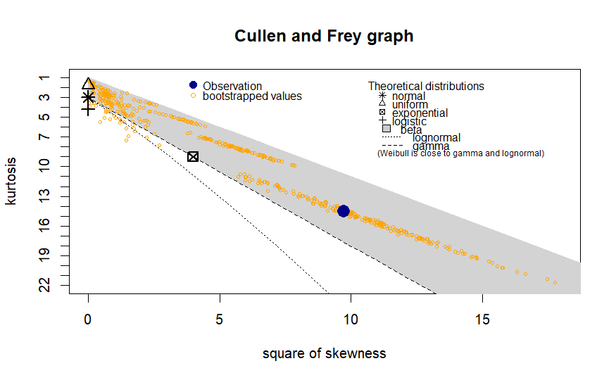

```r
# creating a skew vs. kurtois graph for cycling 1998

# Filter the data based on the "destination" column
c_3_1998 <- cycling_1998 %>%
  filter(destination == "3")
descdist(c_3_1998$DURATION %>% unlist() %>% as.numeric(), discrete=FALSE, boot=500)
```

As shown in the Cullen and Frey graph, we see that gamma, normal, lognormal and exponential will likely be the best fit according to the graph above. Then we compare these models to find the best model.

```r
# Based on the skew vs. kurtois graph the best distribution

#Calculating gamma distribution
gamma_c3_1998_ <- fitdistrplus::fitdist(data=c_3_1998$DURATION%>% unlist() %>% as.numeric(), "gamma", method="mle", optim.method="Nelder-Mead", weights = round(c_3_1998$WGHT_EPI))
fit_dgamma_c398 <- data.frame(f = dgamma(c_3_1998$DURATION, shape = gamma_c3_1998_$estimate[1], rate = gamma_c3_1998_$estimate[2]), x = c_3_1998$DURATION, type = "Gamma")

summary(gamma_c3_1998_)
```

```
Fitting of the distribution ' gamma ' by maximum likelihood
Parameters :
```

|  | estimate | Std. Error |
| --- | --- | --- |
| shape | 1.8920710 | 0.0121866735 |
| rate | 0.1244656 | 0.0009170077 |

```
Loglikelihood:  -149449.3   AIC:  298902.6   BIC:  298904.7
Correlation matrix:
          shape      rate
shape 1.0000000 0.8741325
rate  0.8741325 1.0000000
```

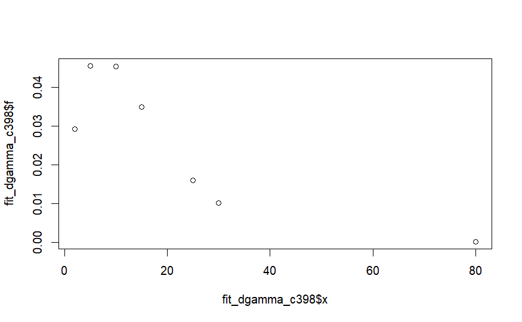

```r
plot(x= fit_dgamma_c398$x, y=fit_dgamma_c398$f)
```

```r
#Calculating normal distribution
norm_c3_1998_ <- fitdistrplus::fitdist(data=c_3_1998$DURATION%>% unlist() %>% as.numeric(), "norm", method="mle", optim.method="Nelder-Mead", weights = round(c_3_1998$WGHT_EPI))
fit_dnorm_c398 <- data.frame(f = dnorm(c_3_1998$DURATION, mean = norm_c3_1998_$estimate[1], sd = norm_c3_1998_$estimate[2]), x = c_3_1998$DURATION, type = "norm")

summary(norm_c3_1998_)
```

```
Fitting of the distribution ' norm ' by maximum likelihood
Parameters :
```

|  | estimate | Std. Error |
| --- | --- | --- |
| mean | 15.20412 | 0.07347397 |
| sd | 14.92643 | 0.05193834 |

```
Loglikelihood:  -170130.3   AIC:  340264.6   BIC:  340266.7
Correlation matrix:
             mean           sd
mean 1.0000000000 0.0002921666
sd   0.0002921666 1.0000000000
```

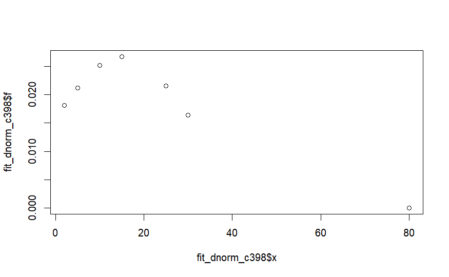

```r
plot(x= fit_dnorm_c398$x, y=fit_dnorm_c398$f)
```

```r
#Calculating lognormal distribution
lnorm_c3_1998_ <- fitdistrplus::fitdist(data=c_3_1998$DURATION%>% unlist() %>% as.numeric(), "lnorm", method="mle", optim.method="Nelder-Mead", weights = round(c_3_1998$WGHT_EPI))
fit_dlnorm_c398 <- data.frame(f = dlnorm(c_3_1998$DURATION, meanlog = lnorm_c3_1998_$estimate[1], sdlog = lnorm_c3_1998_$estimate[2]), x = c_3_1998$DURATION, type = "lnorm")

summary(lnorm_c3_1998_)
```

```
Fitting of the distribution ' lnorm ' by maximum likelihood
Parameters :
```

|  | estimate | Std. Error |
| --- | --- | --- |
| meanlog | 2.4342827 | 0.003544284 |
| sdlog | 0.7200307 | 0.002505804 |

```
Loglikelihood:  -145476.8   AIC:  290957.7   BIC:  290959.8
Correlation matrix:
              meanlog         sdlog
meanlog  1.0000000000 -0.0001194699
sdlog   -0.0001194699  1.0000000000
```

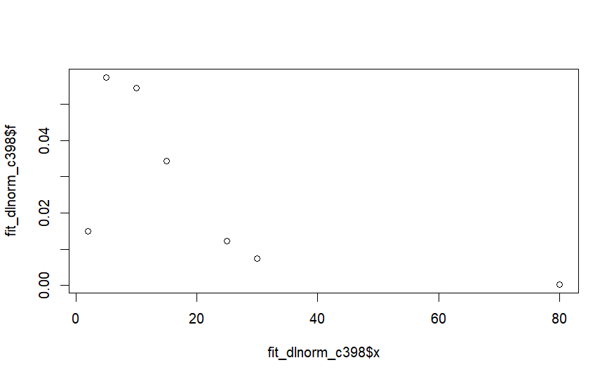

```r
plot(x= fit_dlnorm_c398$x, y=fit_dlnorm_c398$f)
```

```r
#Calculating exponential distribution
exp_c3_1998_ <- fitdistrplus::fitdist(data=c_3_1998$DURATION%>% unlist() %>% as.numeric(), "exp", method="mle", optim.method="Nelder-Mead", weights = round(c_3_1998$WGHT_EPI))
summary(exp_c3_1998_)
```

```
Fitting of the distribution ' exp ' by maximum likelihood
Parameters :
```

|  | estimate | Std. Error |
| --- | --- | --- |
| rate | 0.06577325 | 0.0003236878 |

```
Loglikelihood:  -153584.4   AIC:  307170.8   BIC:  307171.8
```

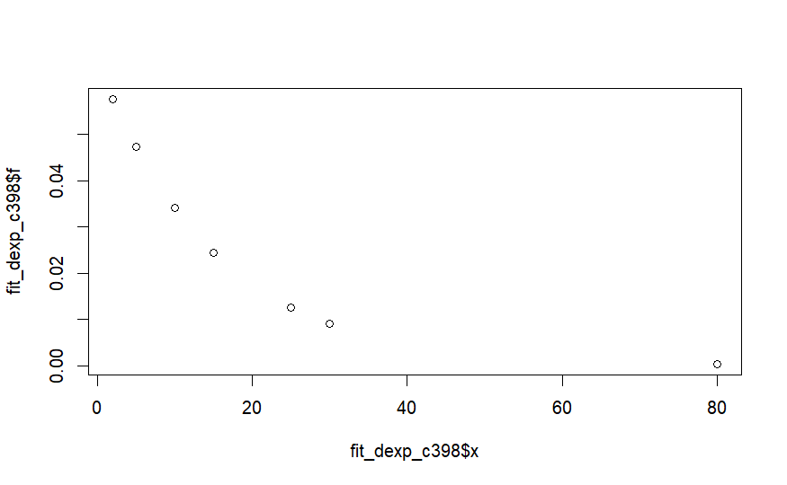

```r
fit_dexp_c398 <- data.frame(f = dexp(c_3_1998$DURATION, rate = exp_c3_1998_$estimate[1]),
                       x = c_3_1998$DURATION, type = "exp")

plot(x = fit_dexp_c398$x, y = fit_dexp_c398$f)
```

Now let’s compare these models AIC and BIC to see which fits the walk data best:

```r
#comparing these models AIC and BIC to see which fits the walk data best:
broom::glance(MASS::fitdistr(c_3_1998$DURATION%>% unlist() %>% as.numeric(),"gamma"))
```

| logLik | AIC | BIC | nobs |
| --- | --- | --- | --- |
| -77.65463 | 159.3093 | 161.3983 | 21 |

```r
broom::glance(MASS::fitdistr(c_3_1998$DURATION%>% unlist() %>% as.numeric(),"normal"))
```

| logLik | AIC | BIC | nobs |
| --- | --- | --- | --- |
| -88.36644 | 180.7329 | 182.8219 | 21 |

```r
broom::glance(MASS::fitdistr(c_3_1998$DURATION%>% unlist() %>% as.numeric(),"lognormal"))
```

| logLik | AIC | BIC | nobs |
| --- | --- | --- | --- |
| -75.86448 | 155.729 | 157.818 | 21 |

```r
broom::glance(MASS::fitdistr(c_3_1998$DURATION%>% unlist() %>% as.numeric(),"exponential"))
```

| logLik | AIC | BIC | nobs |
| --- | --- | --- | --- |
| -78.97286 | 159.9457 | 160.9902 | 21 |

So, lognormal has largest logLik and the smallest AIC and BIC. we will pick lognormal function for cycling trips in 1998!

```r
cycling_398_lnorm <- lnorm_c3_1998_
c_3_1998 <- c_3_1998 %>%
 mutate(f_3 = dlnorm(DURATION, cycling_398_lnorm$estimate["meanlog"], cycling_398_lnorm$estimate["sdlog"]))
summary(c_3_1998$f_3)
```

```
     Min.   1st Qu.    Median      Mean   3rd Qu.      Max.
0.0001784 0.0343618 0.0343618 0.0384939 0.0544872 0.0574938
```

creating a new walking data frame that have all the f values for walking 1998

```r
walking_1998_f <- bind_rows(w_1_1998, w_2_1998, w_3_1998)
```

creating a new cycling data frame that have all the f values for cycling 1998

```r
cycling_1998_f <- bind_rows(c_1_1998, c_2_1998, c_3_1998)
```